# Data Transalation Challenge: Visitors in July/2020 in King County

Everly Ho

5/14/2021

## Introduction

After examining **king_dailyvisits** data, there are some interesting point about number of visit changing daily. These interesting point are visualized as follows:

## Total visit daily in July/2020

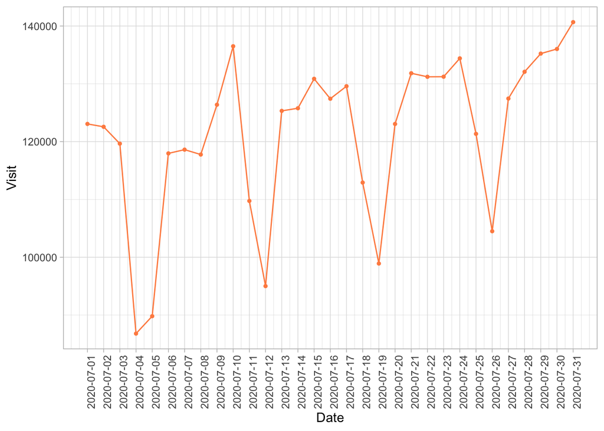

As we can see, total visit drop to its lowest at the weekend and tends to increase gradually towards the end of the month.

## Top 10 Industries have the most visit in July/2020

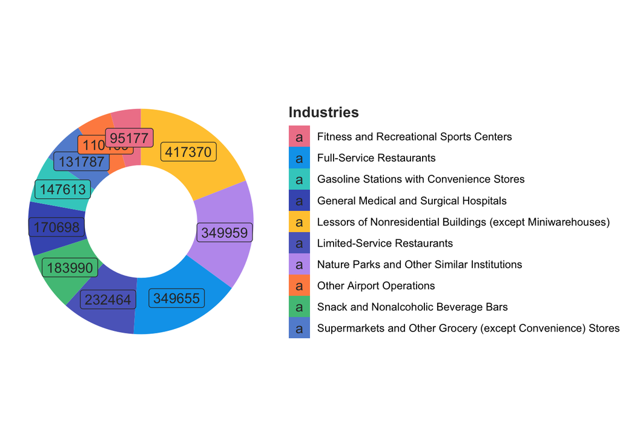

The chart show Industries with the most visit, these are essential services Like accommodation, food and health.

## Top 3 Industries and average daily visit data in July/2020

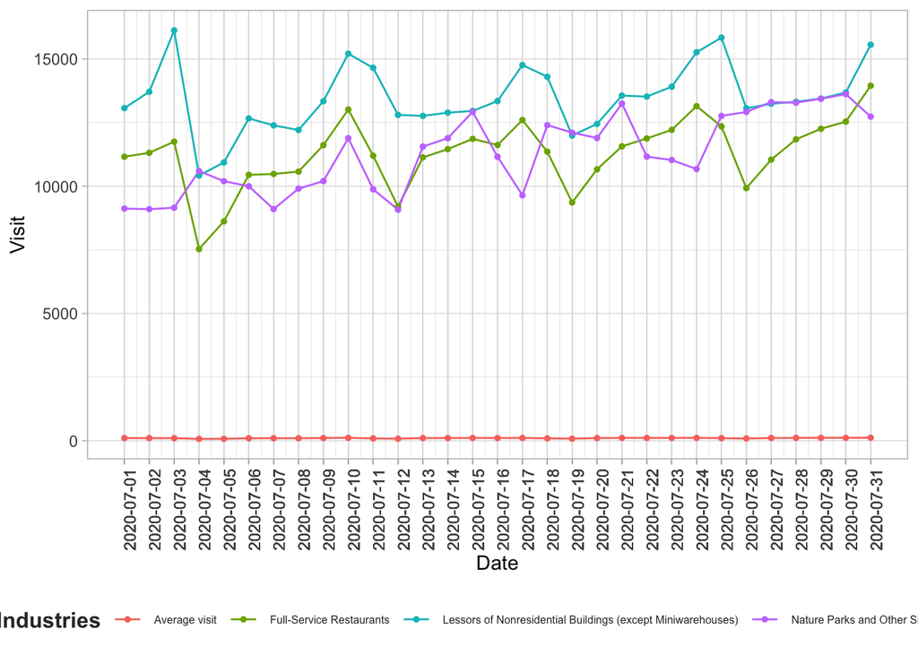

## Total visit of Lessors of Nonresidential Buildings (except Miniwarehouses) brands in July/2020

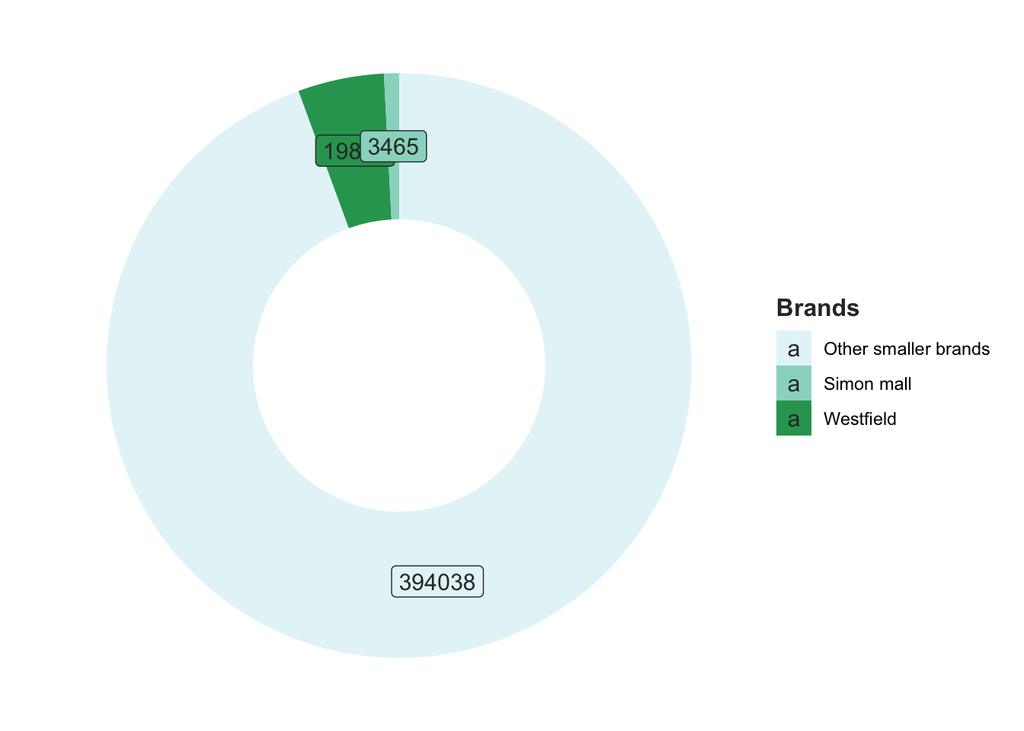

In the most visit industry data, Lessors of Nonresidential Buildings (except Miniwarehouses), We can see that most people support smaller brands.

## Daily visit of Lessors of Nonresidential Buildings (except Miniwarehouses) brands in July/2020

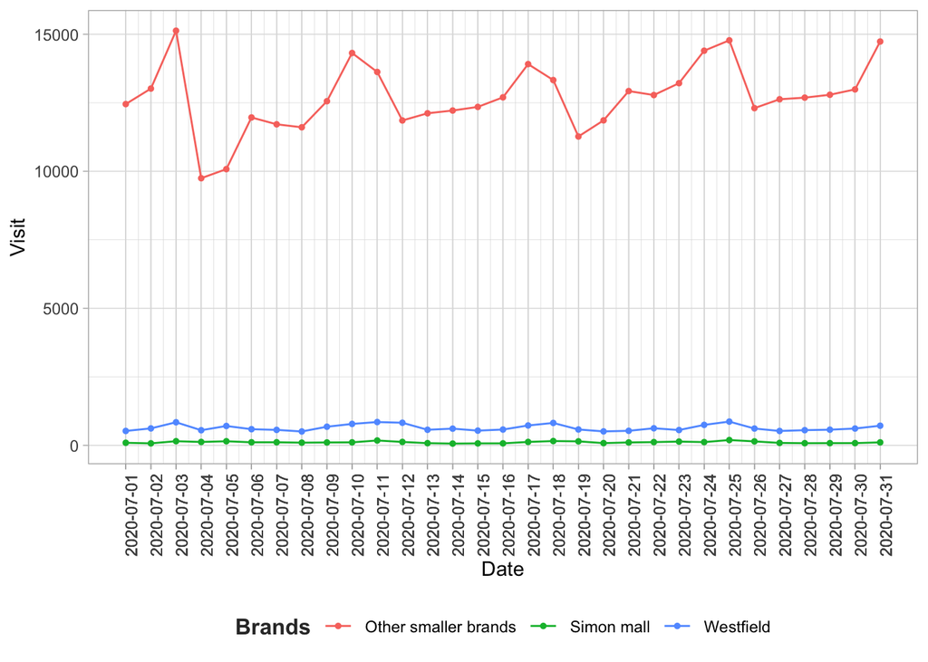

Number of visits of big brands is pretty stable, unlike smaller brands which difference between the highest and the lowest is too large.